# Sally the Congressperson: A Psycho- and Sociolinguistic Investigation into the Relationship Between Ideology, Gender, and Language: Final Processing Model

B. Papineau

Last Updated: Sunday, December 26, 2021

# 1 Introduction

The code and information contained herein constitutes the final model fit developed to analyse the results of my processing study, which was carried out as part of my first Qualifying Paper towards the PhD in Linguistics at Stanford University. I explain herein not only the final developed model, but also the parts which go into it and how we arrived at these, since the data is heavily adjusted from its raw input form (for reasons I hope will be clear throughout this document). Finally, I explain and visualize some of the final results towards the end of this document.

# 2 Preliminaries

## 2.1 Setting up the Notebook

For this write-up and analysis, I require the following packages, loaded in here:

```r
library(ggplot2)
library(tidyverse)
library(lme4)
library(lmerTest)
library(brms)

source("helpers.R")
```

I also use a custom color palette, so I include the code for that here as well[^1]. I also set the default ggplot theme to theme_minimal for personal aesthetic reasons.

```r
bran_palette = c("#7ae7e5", "#fe5f55", "#B2A6DE", "#14342b", "#69385c")

theme_set(theme_minimal())
```

```r
`%notin%` <- Negate(`%in%`)
```

```r
ad_lexemes <- c("actor","host","hunter","villain","heir","hero")
```

## 2.2 Frequency Data

In order to account for potential effects of the relative frequency of these items, we also want to include frequency values for each form and lexeme. Frequencies were collected from the “Spoken” part of the [Corpus of Contemporary American English](https://www.english-corpora.org/coca/). The “Spoken” part of COCA consists of transcripts from ABC, CNN, PBS, NBC, MSNBC, NPR, CBS, and FOX, as well as a small collcetion of independent news sources. We read in the frequency values of the twenty critical items here:

```r
frequency <- read.csv("freq_vals.csv")
```

One of the working questions in this investigation is: what is the role of media influence in the processing and production of these gender-neutral social role titles? In order to investigate this question, we likely shouldn’t ascribe the same frequency values to all participants, especially when the corpus from which the frequency values are derived includes the media source the tokens come from. As such, we can coalesce the left-wing media sources into a single “left-wing frequency” value, and do the same to the right-wing media (which, in COCA, is just FOX). The relative left-vs-right media biases are taken from the [Ad Fontes Media Bias Chart](https://adfontesmedia.com).

```r
lib_cols <- c('ABC','CNN','PBS','NBC','MSNBC','NPR','CBS')
```

```r
frequency <- frequency %>%
  mutate(total_left = rowSums(frequency[lib_cols])) %>%
  mutate(total_right = FOX) %>%
  mutate(all_wpm = ((total_left + total_right) / 121500000) * 1000000) %>%
  mutate(left_wpm = (total_left/109300000) * 1000000) %>%
  mutate(right_wpm = (total_right/12200000) * 1000000) %>%
  mutate(neutral_binary = case_when(
    gender == 'neutral' ~ as.numeric(1),
    TRUE ~ as.numeric(0)
  )) %>%
  mutate(morph_type = case_when(
    lexeme %notin% ad_lexemes ~ "compound",
    TRUE ~ "adoption"
  ))
```

frequency <- frequency %>% group_by(word) %>% summarise(mean_freq_left = mean(left_wpm), mean_freq_right = mean(right_wpm), mean_freq_all = mean(all_wpm)) %>% rename(form = word)

Re-write frequency to avoid zero numbers!

```r
frequency[frequency == 0.00000000] <- 0.0001
```

Take log frequency of each media type.

```r
frequency <- frequency %>%
  mutate(div = all_wpm/1000000) %>%
  mutate(nex = div*100) %>%
  mutate(prob = nex/100) %>%
  mutate(log_all = -log(prob)) %>%
  mutate(div = left_wpm/1000000) %>%
  mutate(nex = div*100) %>%
  mutate(prob = nex/100) %>%
  mutate(log_left = -log(prob)) %>%
  mutate(div =right_wpm/1000000) %>%
  mutate(nex = div*100) %>%
  mutate(prob = nex/100) %>%
  mutate(log_right = -log(prob)) %>%
  rename(form = word) %>%
  select(form,gender,log_all,log_left,log_right)
```

frequency <- frequency %>% mutate(log_right = log(mean_freq_right), log_left = log(mean_freq_left))

Create media difference

frequency <- frequency %>% mutate(media_diff = log_left - log_right) %>% mutate(nonexistent = ifelse(media_diff == 0 & log_left < -4,“true”,“false”))

### 2.2.1 Norming Data

And here is the norming data values:

```r
norming_data <- read.csv("norming_data.csv") %>%
  filter(id!="example1") %>% # Will filter out non-critical trials, i.e. the example trial from the beginning of the experiment
  mutate(equalized_response = case_when(
    scale == 'FM' ~ as.numeric(8)-as.numeric(response),
    TRUE ~ as.numeric(response)
  )) %>%  # This will render all data points on the same scale, as participants randomly received either "very likely a man" or "very likely a woman" as the left end of their response scale, with the other appearing at the right end
  mutate(orthog = ifelse(orthog=="sroceress","sorceress",orthog)) %>% # Fixes a typo
  mutate(id = tolower(id)) %>%
  mutate(id = case_when(
    id == "police_officer" ~ "police officer",
    id == "stunt_double" ~ "stunt double",
    id == 'flight_attendant' ~ 'flight attendant',
    TRUE ~ id
  )) %>%
  mutate(orthog = case_when(
    orthog == 'airline steward' ~ 'steward',
    orthog == 'airline stewardess' ~ 'stewardess',
    TRUE ~ orthog
  ))
```

```r
norming_exclusion <- norming_data %>%
  filter(gender=="female") %>%
  group_by(workerid) %>%
  summarize(female_mean = mean(equalized_response)) %>%
  unique() %>%
  mutate(exclusion = female_mean < mean(female_mean) - 2*sd(female_mean)) %>%
  filter(exclusion==TRUE)
```

```r
norming_data <- norming_data[!(norming_data$workerid %in% norming_exclusion$workerid),]
```

```r
norming_means <- norming_data %>%
  filter(neutral_morh !="male_adoption") %>%
  group_by(orthog,id) %>%
  summarise(indi_mean = mean(equalized_response), trial_count=n()) %>%
  rename(form = orthog) %>%
  rename(lexeme =id)
```

```r
norming_adoptions <- norming_data %>%
  filter(neutral_morh == "male_adoption") %>%
  group_by(orthog) %>%
  summarise(indi_mean = mean(equalized_response), trial_count=n()) %>%
  mutate(lexeme = ifelse(orthog=="actress","actor",ifelse(orthog=="heiress","heir",ifelse(orthog=="heroine","hero",ifelse(orthog=="hostess","host",ifelse(orthog=="huntress","hunter",ifelse(orthog=="villainess","villain",orthog))))))) %>%
    rename(form = orthog)
```

```r
norming_adoptions <- norming_adoptions[, c("lexeme", "form", "indi_mean", "trial_count")]
```

```r
norming_means <- rbind(norming_means,norming_adoptions) %>%
  rename(lexeme_norm = lexeme)
```

**Neutrals Only**

```r
norming_means_neutral <- norming_data %>%
  filter(gender=="neutral") %>%
  filter(neutral_morh !="male_adoption") %>%
  group_by(orthog,id) %>%
  summarise(indi_mean = mean(equalized_response), trial_count=n()) %>%
  rename(form = orthog) %>%
  rename(lexeme =id)
```

```r
norming_adoptions_neutral <- norming_data %>%
  filter(gender=="neutral") %>%
  filter(neutral_morh == "male_adoption") %>%
  group_by(orthog) %>%
  summarise(indi_mean = mean(equalized_response), trial_count=n()) %>%
  mutate(lexeme = ifelse(orthog=="actress","actor",ifelse(orthog=="heiress","heir",ifelse(orthog=="heroine","hero",ifelse(orthog=="hostess","host",ifelse(orthog=="huntress","hunter",ifelse(orthog=="villainess","villain",orthog))))))) %>%
    rename(form = orthog)
```

```r
norming_adoptions_neutral <- norming_adoptions_neutral[, c("lexeme", "form", "indi_mean", "trial_count")]
```

```r
norming_means_neutral <- rbind(norming_means_neutral,norming_adoptions_neutral)
```

# 3 Self-Paced Reading Study

## 3.1 Methods

We originally ran the experiment on 200 participants, recruited through the online participant recruitment platform [Prolific](https://www.prolific.co). The mean time of the experiment was 5.39 minutes, and participants were paid $1.75 for their participation[^2]. The only restrictions placed on participants were that they:

1. Were born in the United States
2. Lived in the United States at the time of participation
3. Spoke English as a first language
4. Had not participated in the norming study for the stimuli

These requirements were implemented in order to assure that speakers came from at least somewhat similar linguistic backgrounds, as certain lexical items in the study (such as *congressperson*) are quite localized to the United States.

After this initial run of the experiment, we found that there was a dearth of conservative or Republican-aligned participants. As a result, we ran the experiment again, this time on 98 self-identified Republicans. This was achieved by adding a filter on Prolific so that only Republican-identified individuals could see the task. The rest of the experiment, including payment, was exactly the same, except that an additional disclaimer that participants could not use the FireFox browser experiment, after the first run revealed an incompatibility between JavaScript and FireFox. The two runs of the experiment amounted in a total of 298 participants who completed the task.

### 3.1.1 Analysis

**Reading in the Data**

```r
sprt_data <- read.csv('sprt_data.csv') %>%
  filter(trial_id!= 'example') %>%
  filter(region=='critical')
```

**Exclusions**

Now, we want to exclude any participants who failed to answer at least 85% of the attention check questions correctly. We do this by creating a list of all participants who scored less than 85% on these checks, and then cross-referencing this list with all data points, removing any data points whose participants were in the exclusion list.

```r
sprt_exclusion <- sprt_data %>% group_by(workerid) %>%
  summarise(accuracy = mean(response_correct)) %>%
  mutate(exclude = case_when(
    accuracy < 0.85 ~ "Yes",
    TRUE ~ "No"
  )) %>%
  filter(exclude == 'Yes')

sprt_data <- sprt_data[!(sprt_data$workerid %in% sprt_exclusion$workerid),]
```

```r
sprt_data <- sprt_data %>%
  group_by(trial_id) %>%
  mutate(id_mean = mean(log(rt))) %>%
  mutate(exclusion = (log(rt) < mean(log(rt)) - 2*sd(log(rt))|(log(rt) > mean(log(rt)) + 2*sd(log(rt))))) %>%
  ungroup() %>%
  filter(exclusion==FALSE)
```

```r
sprt_data <- sprt_data %>%
  filter(!is.na(subject_information.age)) %>%
  filter(!is.na(subject_information.party_alignment))
```

This results in 238 trials being removed from the 5580 we got after the by-participant exclusions. We now have 5342 trials we can use for analysis.

**Additional Information** Now that we have only the rows we want, let’s add some new columns, which will contain important information for each data point. Here, we will be adding:

- Gender Ideology Subscores
- Trial Genders
- Trial Morphology Types
- Critical Item Length & Length-Controlled Residuals
- Trial Congruency
- Partipant Political Affiliation

Ideally, I would’ve added all of these but the first when I actually created the stimuli and logged responses, but I forgot to! Luckily, R allows us to do this post-hoc fairly straightforwardly… which is good, since these features will be critical in our data visualization and analysis.

The question under investigation here is whether or not individuals’ conceptions of gender affect how they process gendered and gender-neutral forms of English personal and professional titles.  
In order to examine this, we need to quanify participants’ ideological views! Here we have adopted the 13-item Social Roles Questionnaire put forth in Baber & Tucker (2006). Questions 1-5 correlate to the *‘Gender Transcendent’* subscale, and questions 6-13 correspond to the *‘Gender Linked’* subscale. Each item is scored on a scale of 0-100. So, the first thing we want to do is make two lists of columns which correspond to these two subscales, since the questions are stored individually in the data:

```r
gender_transcendence_cols <- c('subject_information.gender_q1','subject_information.gender_q2','subject_information.gender_q3','subject_information.gender_q4','subject_information.gender_q5')

gender_linked_cols <- c('subject_information.gender_q6','subject_information.gender_q7','subject_information.gender_q8','subject_information.gender_q9','subject_information.gender_q10','subject_information.gender_q11','subject_information.gender_q12','subject_information.gender_q13')
```

Now we can use the mutate() method on **sprt_data** to add two new columns, one for each subscale. We tell R to take the means of the specified columns in [column_names] of **sprt_data** for each individual row: rowMeans(sprt_data[column_names]). We also have to subtract this mean from 100 in the case of the *‘Gender Transcendent’* subscale, since it is inversely scored. Finally, we can create an average total score regardless of subscores, simply by meaning the two subscores we already have.

```r
sprt_data <- sprt_data %>%
  mutate(gender_trans = 100 - (rowMeans(sprt_data[gender_transcendence_cols]))) %>%
  mutate(gender_link = rowMeans(sprt_data[gender_linked_cols]))

gender_all = c('gender_trans','gender_link')

sprt_data <- sprt_data %>%
  mutate(gender_total = rowMeans(sprt_data[gender_all]))
```

We also want to add whether the trial included a female or male referent (but also, like, destroy the binary!). In order to do this, we’ll just add a **trial_gender** column that says *‘female’* if the condition was either *‘neutral_female’* or *‘congruent_female’*. Otherwise, we want the **trial_gender** to say *‘male’*.

```r
sprt_data <- sprt_data %>%
  mutate(trial_gender = case_when(
    condition == "neutral_female" | condition == "congruent_female" ~ "female",
    TRUE ~ "male"
  ) )

sprt_data %>%
  select(workerid,rt,condition,trial_id,trial_gender)
```

| workerid | rt | condition | trial_id | trial_gender |
| --- | --- | --- | --- | --- |
| 201 | 392 | congruent_female | hero_congruent_female | female |
| 201 | 344 | congruent_female | businessperson_congruent_female | female |
| 201 | 368 | neutral_female | heir_neutral_female | female |
| 201 | 480 | congruent_female | anchor_congruent_female | female |
| 201 | 400 | congruent_male | salesperson_congruent_male | male |
| 201 | 265 | congruent_male | crewmember_congruent_male | male |
| 201 | 344 | congruent_female | stunt double_congruent_female | female |
| 201 | 504 | neutral_male | actor_neutral_male | male |
| 201 | 304 | neutral_male | meteorologist_neutral_male | male |
| 201 | 384 | neutral_female | police officer_neutral_female | female |

[output cut: 990 more lines]

Now we want to add whether or not the lexeme’s neutral form is developed by compounding (as in *‘congress-person’*) or by the adoption of the male form (as in *‘actor’* being used more for both men and women). In this study, we only have six lexemes of the latter type, so we’ll just tell R to assign those a **morph_type** value of *‘adoption’* (for ‘male adoption’), and all else will be assigned a value of *‘compound’*.

```r
sprt_data <- sprt_data%>%
  mutate(morph_type = case_when(
    lexeme %notin% ad_lexemes ~ "compound",
    TRUE ~ "adoption"
  ))

sprt_data %>%
  select(rt,lexeme,morph_type)
```

| rt | lexeme | morph_type |
| --- | --- | --- |
| 392 | hero | adoption |
| 344 | businessperson | compound |
| 368 | heir | adoption |
| 480 | anchor | compound |
| 400 | salesperson | compound |
| 265 | crewmember | compound |
| 344 | stunt double | compound |
| 504 | actor | adoption |
| 304 | meteorologist | compound |
| 384 | police officer | compound |

[output cut: 990 more lines]

Another important factor we want to explore is the length of the critical item! In order to add this, we simply create a new column **form_length** and tell R to input as that column’s value the length of the string that appears in that row’s **form** column, which corresponds to the orthograpic form of the critical item in that trial. *Note that this will include spaces in the count!*

```r
sprt_data <- sprt_data %>%
  mutate(form_length = str_length(form))

sprt_residual_model <- lm(log(rt)~form_length, data = sprt_data)

sprt_data <- sprt_data %>%
  mutate(resid_rt = resid(sprt_residual_model))
```

Now that we have these, we can run a simple linear regression which will show us the effect of orthographic length on reading time. Then we add a new column in the data which is the residual reading time, or the reading time in log space AFTER we control for the effects of orthographic length.

We also want to make sure we have a column which records whether or not the trial was gender-congruent (as in *‘Shelby is a congresswoman’*) or gender neutral (as in *‘Shelby is a congressperson’*). We add a **trial_congruency** column, which is valued as *‘congruent’* if that row’s condition is one of the two congruent conditions. Otherwise, it gets valued as *‘neutral’*.

```r
sprt_data <- sprt_data %>%
  mutate(trial_congruency = case_when(
    condition == "congruent_male" | condition == "congruent_female" ~ "congruent",
    TRUE ~ "neutral"
  ))
```

Finally, we can classify participants by their particular political alignment; we can construe this broadly as “Republicans” vs. “Democrats”, with those who placed themselves in the middle as “Non-Partisan”.

```r
sprt_data <- sprt_data %>%
  mutate(poli_party = case_when(
    subject_information.party_alignment == 1 | subject_information.party_alignment == 2 ~ "Republican",
    subject_information.party_alignment == 4 | subject_information.party_alignment == 5 ~ "Democrat",
    TRUE ~ "Non-Partisan"
  ))
```

```r
sprt_data %>%
  select(workerid,subject_information.party_alignment,poli_party,trial_gender,trial_congruency,condition)
```

| workerid | subject_information.party_alignment | poli_party | trial_gender | trial_congruency | condition |
| --- | --- | --- | --- | --- | --- |
| 201 | 4 | Democrat | female | congruent | congruent_female |
| 201 | 4 | Democrat | female | congruent | congruent_female |
| 201 | 4 | Democrat | female | neutral | neutral_female |
| 201 | 4 | Democrat | female | congruent | congruent_female |
| 201 | 4 | Democrat | male | congruent | congruent_male |
| 201 | 4 | Democrat | male | congruent | congruent_male |
| 201 | 4 | Democrat | female | congruent | congruent_female |
| 201 | 4 | Democrat | male | neutral | neutral_male |
| 201 | 4 | Democrat | male | neutral | neutral_male |
| 201 | 4 | Democrat | female | neutral | neutral_female |

[output cut: 990 more lines]

**Joining independent data** Now that we have this information, we want to left join our frequency information so that we can use it in later analyses. We begin by adding the norming values’ means, of all forms.

```r
final_spr <- left_join(sprt_data,norming_means,by="form")
```

Now we can add the frequency data as well, by form.

```r
final_spr <- left_join(final_spr,frequency,by="form")
```

Now we can add additional lexeme-level norming information for the neutral forms, so that we can tackle the question of what role real-world expectations have on processing times.

```r
final_spr <- left_join(final_spr,norming_means_neutral,by="lexeme")
```

```r
final_spr <- subset(final_spr, select = -c(form.y,trial_count.y,trial_count.x,error,subject_information.asses,subject_information.enjoyment,subject_information.gender_q1,subject_information.gender_q2,subject_information.gender_q3,subject_information.gender_q4,subject_information.gender_q5,subject_information.gender_q6,subject_information.gender_q7,subject_information.gender_q8,subject_information.gender_q9,subject_information.gender_q10,subject_information.gender_q11,subject_information.gender_q12,subject_information.gender_q13,lexeme_norm)) %>%
  rename(form_norm = indi_mean.x, lexeme_norm = indi_mean.y, form = form.x) %>%
  mutate(young_old = ifelse(subject_information.age > 40,"old","young"))
```

mutate(media_source = ifelse(poli_party == “Republican”,log_right,ifelse(poli_party == “Democrat”,log_left,log_all)))

```r
final_spr <- final_spr %>%
  mutate(trial_congruency = as.factor(trial_congruency)) %>%
  mutate(trial_congruency = fct_relevel(trial_congruency,"neutral")) %>%
  mutate(trial_gender = as.factor(trial_gender)) %>%
  mutate(c_gender_total = scale(gender_total,scale=FALSE)) %>%
  mutate(c_gender_trans = scale(gender_trans,scale=FALSE)) %>%
  mutate(c_gender_link = scale(gender_link,scale=FALSE)) %>%
  mutate(c_trial_gender = scale(as.numeric(trial_gender),scale=FALSE)) %>%
  mutate(c_trial_congruency = scale(as.numeric(trial_congruency),scale=FALSE))
```

```r
subject_means <- final_spr %>%
  select(workerid,poli_party,gender_link,gender_total,gender_trans) %>%
  unique()
```

```r
subject_means_w_party <- final_spr %>%
  select(workerid,poli_party,gender_link,gender_total,gender_trans) %>%
  filter(!is.na(poli_party)) %>%
  unique()
```

```r
ideo_residuals <- data.frame(
  subject_means_w_party["workerid"],
  ResidIdeo = lm(gender_total~poli_party, data=subject_means_w_party)$resid
)
```

```r
final_spr <- left_join(final_spr,ideo_residuals,by="workerid")
```

```r
frequency <- frequency %>%
  mutate(gender = ifelse(form== 'anchor' | form== 'businessperson'| form== 'camera operator' | form== 'congressperson'| form== 'craftsperson'| form== 'crewmember'| form== 'firefighter'| form== 'flight attendant'| form== 'foreperson'| form== 'layperson'| form== 'meteorologist'| form== 'police officer'| form== 'salesperson'| form== 'stunt double' | form== 'actor' | form== 'host' | form== 'hunter' | form== 'villain' | form== 'heir' | form== 'hero','neutral','gendered')) %>%
  filter(gender=="neutral") %>%
  rename(lexeme = form)
```

```r
norming_means_neutral <- left_join(norming_means_neutral,frequency,by='lexeme')
```

```r
lex_residuals <- data.frame(
  norming_means_neutral["lexeme"],
  LexResid = lm(indi_mean~log_all, data=norming_means_neutral)$resid
)
```

```r
final_spr <- left_join(final_spr,lex_residuals,by="lexeme")
```

```r
final_spr %>%
  select(lexeme,LexResid) %>%
  unique() %>%
  summarise_all(funs(sum(is.na(.))))
```

| lexeme | LexResid |
| --- | --- |
| 0 | 1 |

```r
final_spr %>%
  select(workerid,poli_party,subject_information.age) %>%
  unique() %>%
  summarise_all(funs(sum(is.na(.))))
```

| workerid | poli_party | subject_information.age |
| --- | --- | --- |
| 0 | 0 | 0 |

```r
final_spr_all <- final_spr
```

```r
final_spr <- final_spr %>%
  filter(trial_congruency == "neutral")
```

```r
final_spr <- final_spr %>%
  mutate(poli_party = factor(poli_party,ordered = FALSE))
```

```r
final_spr$poli_party = relevel(final_spr$poli_party, ref="Non-Partisan")
```

## 3.2 Model

```r
final_spr <- final_spr %>%
  mutate(c_resid_ideo = scale(ResidIdeo))
```

```r
final_spr <- final_spr %>%
  mutate(log_rt = log(rt)) %>%
  mutate(c_form_length = scale(form_length, scale=FALSE))
```

```r
final_spr <- final_spr %>%
  mutate(c_lex_resid = scale(LexResid),scale=FALSE) %>%
  mutate(c_log_all = scale(log_all),scale=FALSE)
```

```r
final_spr$poli_party = relevel(final_spr$poli_party, ref = "Democrat")
```

```r
ultimate_model <- lmer(resid_rt~c_trial_gender*c_gender_total:subject_information.age + c_log_all*poli_party*subject_information.age + c_trial_gender:c_gender_total +  (1 + c_trial_gender |workerid) + (1|lexeme),data=final_spr)
```

```r
summary(ultimate_model)
```

```
Linear mixed model fit by REML. t-tests use Satterthwaite's method ['lmerModLmerTest']
Formula: resid_rt ~ c_trial_gender * c_gender_total:subject_information.age +
    c_log_all * poli_party * subject_information.age + c_trial_gender:c_gender_total +
    (1 + c_trial_gender | workerid) + (1 | lexeme)
   Data: final_spr

REML criterion at convergence: 2250.1

Scaled residuals:
    Min      1Q  Median      3Q     Max
-4.1417 -0.5761 -0.0302  0.5348  3.7409

Random effects:
 Groups   Name           Variance  Std.Dev. Corr
 workerid (Intercept)    0.1297960 0.36027
          c_trial_gender 0.0004837 0.02199  0.68
 lexeme   (Intercept)    0.0028103 0.05301
 Residual                0.0982503 0.31345
Number of obs: 2638, groups:  workerid, 274; lexeme, 20

Fixed effects:
                                                           Estimate Std. Error         df t value Pr(>|t|)
(Intercept)                                              -4.014e-01  1.071e-01  2.684e+02  -3.746 0.000220 ***
c_trial_gender                                           -7.273e-03  1.235e-02  2.557e+02  -0.589 0.556516
c_log_all                                                -5.784e-02  3.135e-02  4.674e+02  -1.845 0.065632 .
poli_partyNon-Partisan                                    3.392e-01  1.716e-01  2.622e+02   1.976 0.049193 *
poli_partyRepublican                                      7.158e-02  1.537e-01  2.637e+02   0.466 0.641799
subject_information.age                                   9.759e-03  3.272e-03  2.635e+02   2.983 0.003125 **
c_gender_total:subject_information.age                   -1.543e-04  4.520e-05  2.654e+02  -3.414 0.000741 ***
c_log_all:poli_partyNon-Partisan                          1.119e-01  4.749e-02  2.347e+03   2.356 0.018578 *
c_log_all:poli_partyRepublican                            3.683e-02  4.273e-02  2.352e+03   0.862 0.388819
subject_information.age:c_log_all                         2.084e-03  8.662e-04  2.269e+03   2.406 0.016208 *
subject_information.age:poli_partyNon-Partisan           -6.841e-03  5.012e-03  2.620e+02  -1.365 0.173463
subject_information.age:poli_partyRepublican              1.618e-03  4.387e-03  2.645e+02   0.369 0.712489
c_trial_gender:c_gender_total                             1.713e-04  2.432e-03  2.673e+02   0.070 0.943905
c_trial_gender:c_gender_total:subject_information.age    -2.606e-06  6.698e-05  2.669e+02  -0.039 0.968994
subject_information.age:c_log_all:poli_partyNon-Partisan -3.521e-03  1.383e-03  2.336e+03  -2.546 0.010950 *
subject_information.age:c_log_all:poli_partyRepublican   -9.640e-04  1.182e-03  2.338e+03  -0.816 0.414660
---
Signif. codes:  0 ‘***’ 0.001 ‘**’ 0.01 ‘*’ 0.05 ‘.’ 0.1 ‘ ’ 1
```

```
Correlation matrix not shown by default, as p = 16 > 12.
Use print(x, correlation=TRUE)  or
    vcov(x)        if you need it
```

```
fit warnings:
Some predictor variables are on very different scales: consider rescaling
```

```r
ultimate_model_unmutated <- lmer(resid_rt~gender_total:subject_information.age + log_all*poli_party*subject_information.age + gender_total:poli_party + trial_gender + gender_total + (1 |workerid) + (1|lexeme),data=final_spr)
```

```r
summary(ultimate_model_unmutated)
```

```
Linear mixed model fit by REML. t-tests use Satterthwaite's method ['lmerModLmerTest']
Formula: resid_rt ~ gender_total:subject_information.age + log_all * poli_party *
    subject_information.age + gender_total:poli_party + trial_gender +      gender_total + (1 | workerid) + (1 | lexeme)
   Data: final_spr

REML criterion at convergence: 2256.2

Scaled residuals:
    Min      1Q  Median      3Q     Max
-4.1725 -0.5751 -0.0358  0.5333  3.7860

Random effects:
 Groups   Name        Variance Std.Dev.
 workerid (Intercept) 0.129972 0.36052
 lexeme   (Intercept) 0.002791 0.05283
 Residual             0.098285 0.31351
Number of obs: 2638, groups:  workerid, 274; lexeme, 20

Fixed effects:
                                                         Estimate Std. Error         df t value Pr(>|t|)
(Intercept)                                            -1.032e-01  2.221e-01  7.118e+02  -0.465   0.6422
log_all                                                -2.384e-02  1.307e-02  4.677e+02  -1.825   0.0687 .
poli_partyNon-Partisan                                 -8.862e-02  3.398e-01  1.257e+03  -0.261   0.7943
poli_partyRepublican                                    1.078e-01  3.261e-01  1.048e+03   0.330   0.7411
subject_information.age                                 1.208e-03  6.037e-03  1.393e+03   0.200   0.8415
trial_gendermale                                       -7.205e-03  1.228e-02  2.344e+03  -0.587   0.5574
gender_total                                           -5.737e-04  5.471e-03  2.621e+02  -0.105   0.9166
gender_total:subject_information.age                   -2.556e-05  1.487e-04  2.633e+02  -0.172   0.8637
log_all:poli_partyNon-Partisan                          4.660e-02  1.979e-02  2.356e+03   2.354   0.0186 *
log_all:poli_partyRepublican                            1.469e-02  1.780e-02  2.359e+03   0.825   0.4095
subject_information.age:log_all                         8.586e-04  3.610e-04  2.367e+03   2.378   0.0175 *
subject_information.age:poli_partyNon-Partisan          1.044e-02  9.204e-03  1.655e+03   1.135   0.2567
subject_information.age:poli_partyRepublican            3.782e-03  8.364e-03  1.385e+03   0.452   0.6512
gender_total:poli_partyNon-Partisan                    -5.814e-03  4.339e-03  2.603e+02  -1.340   0.1815
gender_total:poli_partyRepublican                      -5.999e-03  3.974e-03  2.612e+02  -1.509   0.1324
subject_information.age:log_all:poli_partyNon-Partisan -1.465e-03  5.760e-04  2.359e+03  -2.544   0.0110 *
subject_information.age:log_all:poli_partyRepublican   -3.857e-04  4.919e-04  2.361e+03  -0.784   0.4331
---
Signif. codes:  0 ‘***’ 0.001 ‘**’ 0.01 ‘*’ 0.05 ‘.’ 0.1 ‘ ’ 1
```

```
Correlation matrix not shown by default, as p = 17 > 12.
Use print(x, correlation=TRUE)  or
    vcov(x)        if you need it
```

```r
final_spr$poli_party = relevel(final_spr$poli_party, ref = "Democrat")
```

```r
lmer(resid_rt~gender_total:subject_information.age + log_all*poli_party*subject_information.age + gender_total + trial_gender + (1 |workerid) + (1|lexeme),data=final_spr) %>%
  anova()
```

```
Type III Analysis of Variance Table with Satterthwaite's method
                                            Sum Sq Mean Sq NumDF   DenDF F value  Pr(>F)
log_all                                    0.01341 0.01341     1  136.04  0.1365 0.71240
poli_party                                 0.06441 0.03221     2 1628.52  0.3277 0.72065
subject_information.age                    0.20349 0.20349     1  663.33  2.0703 0.15066
gender_total                               0.03822 0.03822     1  264.65  0.3888 0.53346
trial_gender                               0.03365 0.03365     1 2343.48  0.3423 0.55855
gender_total:subject_information.age       0.02363 0.02363     1  265.26  0.2404 0.62435
log_all:poli_party                         0.55315 0.27657     2 2356.93  2.8138 0.06018 .
subject_information.age:log_all            0.11805 0.11805     1 2356.17  1.2011 0.27322
subject_information.age:poli_party         0.17137 0.08569     2 1606.99  0.8718 0.41841
subject_information.age:log_all:poli_party 0.66102 0.33051     2 2357.43  3.3625 0.03481 *
---
Signif. codes:  0 ‘***’ 0.001 ‘**’ 0.01 ‘*’ 0.05 ‘.’ 0.1 ‘ ’ 1
```

```r
final_spr$poli_party = as.factor(final_spr$poli_party)
```

```r
final_spr$poli_party = relevel(final_spr$poli_party, ref="Democrat")
```

```r
ultimate_model_dem <- lmer(resid_rt~gender_total:subject_information.age + log_all*poli_party*subject_information.age + gender_total + trial_gender + (1 |workerid) + (1|lexeme),data=final_spr)
```

residrt as predicted by gender_total + trial_gender + log_all+subject_age+poli_party + log_all:poli_party + log_all:subject_age + poli_party:subject_age + gender_total:age

```r
summary(ultimate_model_dem)
```

```
Linear mixed model fit by REML. t-tests use Satterthwaite's method ['lmerModLmerTest']
Formula: resid_rt ~ gender_total:subject_information.age + log_all * poli_party *
    subject_information.age + gender_total + trial_gender + (1 |      workerid) + (1 | lexeme)
   Data: final_spr

REML criterion at convergence: 2240.3

Scaled residuals:
    Min      1Q  Median      3Q     Max
-4.1689 -0.5747 -0.0370  0.5378  3.7736

Random effects:
 Groups   Name        Variance Std.Dev.
 workerid (Intercept) 0.130279 0.36094
 lexeme   (Intercept) 0.002786 0.05278
 Residual             0.098291 0.31351
Number of obs: 2638, groups:  workerid, 274; lexeme, 20

Fixed effects:
                                                         Estimate Std. Error         df t value Pr(>|t|)
(Intercept)                                            -2.761e-02  2.170e-01  7.135e+02  -0.127   0.8988
log_all                                                -2.408e-02  1.306e-02  4.687e+02  -1.843   0.0660 .
poli_partyNon-Partisan                                 -2.542e-01  3.155e-01  1.690e+03  -0.806   0.4206
poli_partyRepublican                                   -8.406e-02  2.955e-01  1.494e+03  -0.284   0.7761
subject_information.age                                 8.407e-04  6.027e-03  1.408e+03   0.139   0.8891
gender_total                                           -3.217e-03  5.159e-03  2.647e+02  -0.624   0.5335
trial_gendermale                                       -7.183e-03  1.228e-02  2.343e+03  -0.585   0.5585
gender_total:subject_information.age                   -7.056e-05  1.439e-04  2.653e+02  -0.490   0.6243
log_all:poli_partyNon-Partisan                          4.686e-02  1.979e-02  2.356e+03   2.367   0.0180 *
log_all:poli_partyRepublican                            1.505e-02  1.780e-02  2.359e+03   0.846   0.3979
subject_information.age:log_all                         8.664e-04  3.610e-04  2.368e+03   2.400   0.0165 *
subject_information.age:poli_partyNon-Partisan          1.207e-02  9.152e-03  1.695e+03   1.319   0.1874
subject_information.age:poli_partyRepublican            5.749e-03  8.255e-03  1.455e+03   0.696   0.4863
subject_information.age:log_all:poli_partyNon-Partisan -1.474e-03  5.760e-04  2.359e+03  -2.559   0.0106 *
subject_information.age:log_all:poli_partyRepublican   -3.957e-04  4.919e-04  2.361e+03  -0.805   0.4211
---
Signif. codes:  0 ‘***’ 0.001 ‘**’ 0.01 ‘*’ 0.05 ‘.’ 0.1 ‘ ’ 1
```

```
Correlation matrix not shown by default, as p = 15 > 12.
Use print(x, correlation=TRUE)  or
    vcov(x)        if you need it
```

### 3.2.1 REps

```r
final_spr$poli_party = relevel(final_spr$poli_party, ref="Republican")
```

```r
reps_spr <- final_spr %>%
  filter(poli_party == "Republican") %>%
  filter(young_old == "old")
```

```r
ultimate_model_rep <- lmer(resid_rt~gender_total + log_all + gender_total + trial_gender + (1 |workerid) + (1|lexeme),data=reps_spr)
```

```r
summary(ultimate_model_rep)
```

```
Linear mixed model fit by REML. t-tests use Satterthwaite's method ['lmerModLmerTest']
Formula: resid_rt ~ gender_total + log_all + gender_total + trial_gender +      (1 | workerid) + (1 | lexeme)
   Data: reps_spr

REML criterion at convergence: 159.9

Scaled residuals:
     Min       1Q   Median       3Q      Max
-3.05492 -0.52954 -0.01704  0.59723  2.82860

Random effects:
 Groups   Name        Variance Std.Dev.
 workerid (Intercept) 0.135289 0.36782
 lexeme   (Intercept) 0.005024 0.07088
 Residual             0.068593 0.26190
Number of obs: 270, groups:  workerid, 28; lexeme, 20

Fixed effects:
                   Estimate Std. Error         df t value Pr(>|t|)
(Intercept)        0.273527   0.200209  44.936036   1.366   0.1787
gender_total      -0.007753   0.004395  25.959690  -1.764   0.0895 .
log_all            0.017060   0.009504  17.710492   1.795   0.0897 .
trial_gendermale   0.027366   0.032227 230.812981   0.849   0.3967
---
Signif. codes:  0 ‘***’ 0.001 ‘**’ 0.01 ‘*’ 0.05 ‘.’ 0.1 ‘ ’ 1

Correlation of Fixed Effects:
            (Intr) gndr_t log_ll
gender_totl -0.684
log_all     -0.632  0.009
tril_gndrml -0.082 -0.003  0.002
```

# 4 Demographic Information

```r
demographic <- final_spr %>%
  mutate(poli_party = case_when(
    subject_information.party_alignment == 1 | subject_information.party_alignment == 2 ~ "Republican",
    subject_information.party_alignment == 3 ~ "Non-Partisan",
    subject_information.party_alignment == 4 | subject_information.party_alignment == 5 ~ "Democrat",
  )) %>%
  select(workerid,poli_party,subject_information.gender,time_in_minutes,young_old) %>%
  group_by(workerid) %>%
  unique()
```

```r
table(demographic$subject_information.gender,demographic$poli_party)
```

```
         Democrat Non-Partisan Republican
                0            0          2
  Female       64           34         41
  Male         46           25         59
  Other         3            0          0
```

```r
summary(demographic)
```

```
    workerid      poli_party        subject_information.gender time_in_minutes   young_old
 Min.   :125.0   Length:274         Length:274                 Min.   : 2.181   Length:274
 1st Qu.:211.2   Class :character   Class :character           1st Qu.: 3.840   Class :character
 Median :290.5   Mode  :character   Mode  :character           Median : 4.868   Mode  :character
 Mean   :404.4                                                 Mean   : 5.305
 3rd Qu.:710.8                                                 3rd Qu.: 6.158
 Max.   :801.0                                                 Max.   :23.098
```

# 5 Visualisations

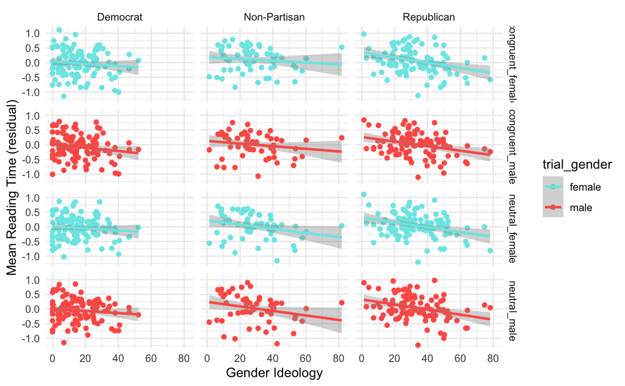

```r
sprt_data %>%
  filter(!is.na(poli_party)) %>%
  group_by(gender_total,workerid,trial_gender,poli_party,condition) %>%
  summarise(meanrt = mean(resid_rt)) %>%
  ggplot(aes(x=gender_total,y=meanrt,color=trial_gender)) +
  geom_point() +
  geom_smooth(method='lm') +
  scale_color_manual(values = bran_palette) +
  facet_grid(condition~poli_party) +
  labs(x="Gender Ideology", y="Mean Reading Time (residual)")
```

```r
ggsave("sprt-neutral-3x3.png", width=10,height=5,path='/Users/branpap/Desktop/gender_ideology/talks_and_papers/qp_paper/figures')
```

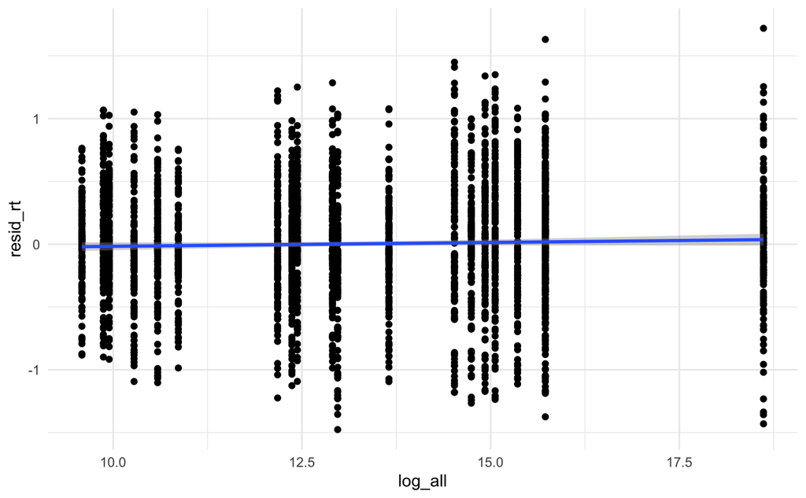

```r
final_spr %>%
  filter(!is.na(poli_party)) %>%
  ggplot(aes(x=log_all,y=resid_rt)) +
  geom_point() +
  geom_smooth(method='lm') +
  scale_color_manual(values = bran_palette)
```

```r
  labs(x="Gender Ideology", y="Mean Reading Time (residual)")
```

```
$x
[1] "Gender Ideology"

$y
[1] "Mean Reading Time (residual)"

attr(,"class")
[1] "labels"
```

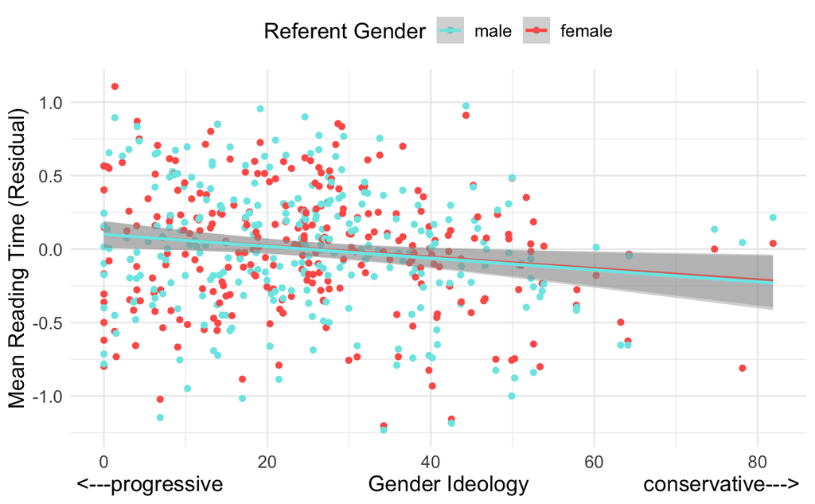

```r
final_spr %>%
  filter(!is.na(poli_party)) %>%
  group_by(gender_total,workerid,trial_gender) %>%
  summarise(meanrt = mean(resid_rt)) %>%
  ggplot(aes(x=gender_total,y=meanrt,color=trial_gender)) +
  geom_point() +
  geom_smooth(method='lm') +
  scale_color_manual(values = bran_palette, limits=c("male","female")) +
  labs(x="<---progressive                        Gender Ideology                   conservative--->", y="Mean Reading Time (Residual)", color="Referent Gender") +
  theme(legend.position = "top", text = element_text(size=14))
```

```r
NA
```

```r
ggsave("sprt-neutral-ideo.png", width=7,height=5,path='/Users/branpap/Desktop/gender_ideology/talks_and_papers/qp_paper/figures')
```

## 5.1 All Region Data

```r
sprt_data_all <- read.csv('sprt_data.csv') %>%
  filter(trial_id!= 'example')
```

**Exclusions**

```r
sprt_data_all <- sprt_data_all[!(sprt_data_all$workerid %in% sprt_exclusion$workerid),]
```

```r
sprt_data_all <- sprt_data_all %>%
  group_by(trial_id) %>%
  mutate(id_mean = mean(log(rt))) %>%
  mutate(exclusion = (log(rt) < mean(log(rt)) - 2*sd(log(rt))|(log(rt) > mean(log(rt)) + 2*sd(log(rt))))) %>%
  ungroup() %>%
  filter(exclusion==FALSE)
```

```r
sprt_data_all <- sprt_data_all %>%
  filter(!is.na(subject_information.age)) %>%
  filter(!is.na(subject_information.party_alignment))
```

**Additional Information** Now that we have only the rows we want, let’s add some new columns, which will contain important information for each data point. Here, we will be adding:

- Gender Ideology Subscores
- Trial Genders
- Trial Morphology Types
- Critical Item Length & Length-Controlled Residuals
- Trial Congruency
- Partipant Political Affiliation

Ideally, I would’ve added all of these but the first when I actually created the stimuli and logged responses, but I forgot to! Luckily, R allows us to do this post-hoc fairly straightforwardly… which is good, since these features will be critical in our data visualization and analysis.

The question under investigation here is whether or not individuals’ conceptions of gender affect how they process gendered and gender-neutral forms of English personal and professional titles.  
In order to examine this, we need to quanify participants’ ideological views! Here we have adopted the 13-item Social Roles Questionnaire put forth in Baber & Tucker (2006). Questions 1-5 correlate to the *‘Gender Transcendent’* subscale, and questions 6-13 correspond to the *‘Gender Linked’* subscale. Each item is scored on a scale of 0-100. So, the first thing we want to do is make two lists of columns which correspond to these two subscales, since the questions are stored individually in the data:

Now we can use the mutate() method on **sprt_data** to add two new columns, one for each subscale. We tell R to take the means of the specified columns in [column_names] of **sprt_data** for each individual row: rowMeans(sprt_data[column_names]). We also have to subtract this mean from 100 in the case of the *‘Gender Transcendent’* subscale, since it is inversely scored. Finally, we can create an average total score regardless of subscores, simply by meaning the two subscores we already have.

```r
sprt_data_all <- sprt_data_all %>%
  mutate(gender_trans = 100 - (rowMeans(sprt_data_all[gender_transcendence_cols]))) %>%
  mutate(gender_link = rowMeans(sprt_data_all[gender_linked_cols]))

gender_all = c('gender_trans','gender_link')

sprt_data_all <- sprt_data_all %>%
  mutate(gender_total = rowMeans(sprt_data_all[gender_all]))
```

We also want to add whether the trial included a female or male referent (but also, like, destroy the binary!). In order to do this, we’ll just add a **trial_gender** column that says *‘female’* if the condition was either *‘neutral_female’* or *‘congruent_female’*. Otherwise, we want the **trial_gender** to say *‘male’*.

```r
sprt_data_all <- sprt_data_all %>%
  mutate(trial_gender = case_when(
    condition == "neutral_female" | condition == "congruent_female" ~ "female",
    TRUE ~ "male"
  ) )

sprt_data_all %>%
  select(workerid,rt,condition,trial_id,trial_gender)
```

| workerid | rt | condition | trial_id | trial_gender |
| --- | --- | --- | --- | --- |
| 201 | 401 | congruent_female | hero_congruent_female | female |
| 201 | 352 | congruent_female | hero_congruent_female | female |
| 201 | 296 | congruent_female | hero_congruent_female | female |
| 201 | 392 | congruent_female | hero_congruent_female | female |
| 201 | 432 | congruent_female | hero_congruent_female | female |
| 201 | 408 | congruent_female | hero_congruent_female | female |
| 201 | 480 | congruent_female | hero_congruent_female | female |
| 201 | 408 | congruent_female | hero_congruent_female | female |
| 201 | 761 | congruent_female | hero_congruent_female | female |
| 201 | 336 | congruent_female | businessperson_congruent_female | female |

[output cut: 990 more lines]

Now we want to add whether or not the lexeme’s neutral form is developed by compounding (as in *‘congress-person’*) or by the adoption of the male form (as in *‘actor’* being used more for both men and women). In this study, we only have six lexemes of the latter type, so we’ll just tell R to assign those a **morph_type** value of *‘adoption’* (for ‘male adoption’), and all else will be assigned a value of *‘compound’*.

```r
sprt_data_all <- sprt_data_all%>%
  mutate(morph_type = case_when(
    lexeme %notin% ad_lexemes ~ "compound",
    TRUE ~ "adoption"
  ))

sprt_data_all %>%
  select(rt,lexeme,morph_type)
```

| rt | lexeme | morph_type |
| --- | --- | --- |
| 401 | hero | adoption |
| 352 | hero | adoption |
| 296 | hero | adoption |
| 392 | hero | adoption |
| 432 | hero | adoption |
| 408 | hero | adoption |
| 480 | hero | adoption |
| 408 | hero | adoption |
| 761 | hero | adoption |
| 336 | businessperson | compound |

[output cut: 990 more lines]

Another important factor we want to explore is the length of the critical item! In order to add this, we simply create a new column **form_length** and tell R to input as that column’s value the length of the string that appears in that row’s **form** column, which corresponds to the orthograpic form of the critical item in that trial. *Note that this will include spaces in the count!*

```r
sprt_data_all <- sprt_data_all %>%
  mutate(form_length = str_length(form))

sprt_residual_model <- lm(log(rt)~form_length, data = sprt_data_all)

sprt_data_all <- sprt_data_all %>%
  mutate(resid_rt = resid(sprt_residual_model))
```

Now that we have these, we can run a simple linear regression which will show us the effect of orthographic length on reading time. Then we add a new column in the data which is the residual reading time, or the reading time in log space AFTER we control for the effects of orthographic length.

We also want to make sure we have a column which records whether or not the trial was gender-congruent (as in *‘Shelby is a congresswoman’*) or gender neutral (as in *‘Shelby is a congressperson’*). We add a **trial_congruency** column, which is valued as *‘congruent’* if that row’s condition is one of the two congruent conditions. Otherwise, it gets valued as *‘neutral’*.

```r
sprt_data_all <- sprt_data_all %>%
  mutate(trial_congruency = case_when(
    condition == "congruent_male" | condition == "congruent_female" ~ "congruent",
    TRUE ~ "neutral"
  ))
```

Finally, we can classify participants by their particular political alignment; we can construe this broadly as “Republicans” vs. “Democrats”, with those who placed themselves in the middle as “Non-Partisan”.

```r
sprt_data_all <- sprt_data_all %>%
  mutate(poli_party = case_when(
    subject_information.party_alignment == 1 | subject_information.party_alignment == 2 ~ "Republican",
    subject_information.party_alignment == 4 | subject_information.party_alignment == 5 ~ "Democrat",
    TRUE ~ "Non-Partisan"
  ))
```

```r
sprt_data_all %>%
  select(workerid,subject_information.party_alignment,poli_party,trial_gender,trial_congruency,condition,word_idx)
```

| workerid | subject_information.party_alignment | poli_party | trial_gender | trial_congruency | condition | word_idx |
| --- | --- | --- | --- | --- | --- | --- |
| 201 | 4 | Democrat | female | congruent | congruent_female | 0 |
| 201 | 4 | Democrat | female | congruent | congruent_female | 1 |
| 201 | 4 | Democrat | female | congruent | congruent_female | 2 |
| 201 | 4 | Democrat | female | congruent | congruent_female | 3 |
| 201 | 4 | Democrat | female | congruent | congruent_female | 4 |
| 201 | 4 | Democrat | female | congruent | congruent_female | 5 |
| 201 | 4 | Democrat | female | congruent | congruent_female | 6 |
| 201 | 4 | Democrat | female | congruent | congruent_female | 7 |
| 201 | 4 | Democrat | female | congruent | congruent_female | 8 |
| 201 | 4 | Democrat | female | congruent | congruent_female | 0 |

[output cut: 990 more lines]

### 5.1.1 Graph

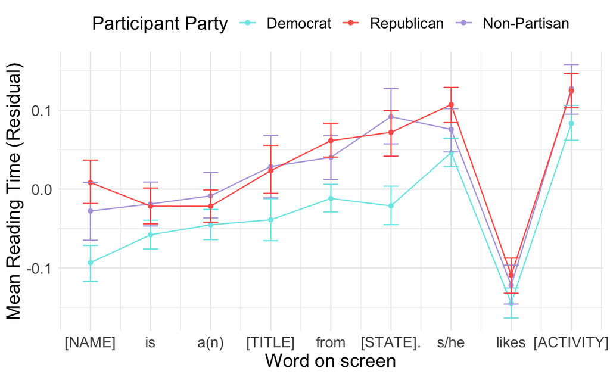

```r
sprt_data_all %>%
  filter(trial_congruency == "neutral") %>%
  group_by(poli_party,word_idx) %>%
  summarize(MeanRT = mean(resid_rt), CI.Low = ci.low(resid_rt), CI.High = ci.high(resid_rt)) %>%
  mutate(YMin = MeanRT - CI.Low, YMax = MeanRT + CI.High) %>%
  ggplot(aes(x=word_idx,y=MeanRT,color=poli_party)) +
  geom_point() +
  geom_line() +
  geom_errorbar(aes(ymin=YMin,ymax=YMax), width=.25) +
  scale_color_manual(values=bran_palette, limits=c("Democrat","Republican","Non-Partisan")) +
  labs(x="Word on screen",y="Mean Reading Time (Residual)",color="Participant Party") +
  scale_x_continuous(labels=c("[NAME]","is","a(n)","[TITLE]","from","[STATE].","s/he","likes","[ACTIVITY]"), breaks=0:8) +
  theme(text = element_text(size=16)) +
  theme(legend.position = "top")
```

```r
ggsave("sprt-neutral-all-regions-poli-party.png", width=7,height=5,path='/Users/branpap/Desktop/gender_ideology/talks_and_papers/qp_paper/figures')
```

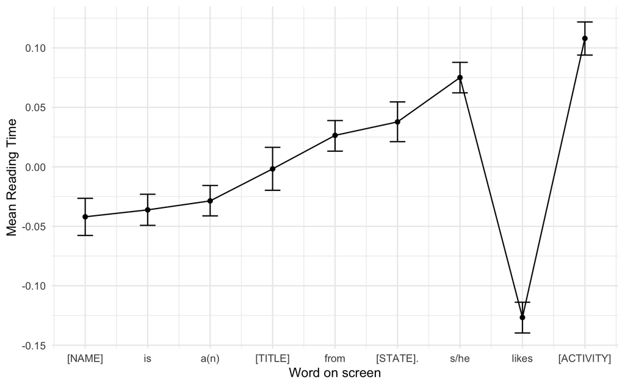

```r
sprt_data_all %>%
  filter(trial_congruency == "neutral") %>%
  group_by(word_idx) %>%
  summarize(MeanRT = mean(resid_rt), CI.Low = ci.low(resid_rt), CI.High = ci.high(resid_rt)) %>%
  mutate(YMin = MeanRT - CI.Low, YMax = MeanRT + CI.High) %>%
  ggplot(aes(x=word_idx,y=MeanRT)) +
  geom_point() +
  geom_line() +
  geom_errorbar(aes(ymin=YMin,ymax=YMax), width=.25) +
  scale_color_manual(values=bran_palette) +
  labs(x="Word on screen",y="Mean Reading Time",color="Participant Political Party") +
  scale_x_continuous(labels=c("[NAME]","is","a(n)","[TITLE]","from","[STATE].","s/he","likes","[ACTIVITY]"), breaks=0:8)
```

```r
ggsave("sprt_neutral_all_regions.png", width=7,height=5,path='/Users/branpap/Desktop/gender_processing/talks_and_papers/qp_paper/figures')
```

```r
sprt_prefix <- sprt_data_all %>%
  filter(word_idx <= 2)
```

```r
all_model <- lmer(resid_rt~gender_total:subject_information.age + poli_party*subject_information.age + gender_total + trial_gender + (1 |workerid) + (1|lexeme),data=sprt_data_all)
```

```r
summary(all_model)
```

```
Linear mixed model fit by REML. t-tests use Satterthwaite's method ['lmerModLmerTest']
Formula: resid_rt ~ gender_total:subject_information.age + poli_party *
    subject_information.age + gender_total + trial_gender + (1 |      workerid) + (1 | lexeme)
   Data: sprt_data_all

REML criterion at convergence: 21248.1

Scaled residuals:
    Min      1Q  Median      3Q     Max
-5.1186 -0.6065 -0.0514  0.5581  4.8159

Random effects:
 Groups   Name        Variance  Std.Dev.
 workerid (Intercept) 0.0499600 0.22352
 lexeme   (Intercept) 0.0001671 0.01293
 Residual             0.0891015 0.29850
Number of obs: 47342, groups:  workerid, 275; lexeme, 20

Fixed effects:
                                                 Estimate Std. Error         df t value Pr(>|t|)
(Intercept)                                    -2.404e-01  7.866e-02  2.677e+02  -3.056 0.002472 **
poli_partyNon-Partisan                          2.178e-01  1.071e-01  2.667e+02   2.035 0.042878 *
poli_partyRepublican                            1.254e-01  1.059e-01  2.669e+02   1.184 0.237476
subject_information.age                         8.295e-03  2.212e-03  2.669e+02   3.751 0.000216 ***
gender_total                                   -4.175e-03  3.083e-03  2.669e+02  -1.354 0.176763
trial_gendermale                               -8.171e-03  2.749e-03  4.705e+04  -2.972 0.002956 **
gender_total:subject_information.age            4.188e-05  8.598e-05  2.670e+02   0.487 0.626623
subject_information.age:poli_partyNon-Partisan -4.156e-03  3.100e-03  2.667e+02  -1.340 0.181248
subject_information.age:poli_partyRepublican   -1.716e-03  2.992e-03  2.670e+02  -0.574 0.566773
---
Signif. codes:  0 ‘***’ 0.001 ‘**’ 0.01 ‘*’ 0.05 ‘.’ 0.1 ‘ ’ 1

Correlation of Fixed Effects:
            (Intr) pl_N-P pl_prR sbjc_. gndr_t trl_gn gn_:_. s_.:_N
pl_prtyNn-P -0.326
pl_prtyRpbl -0.203  0.485
sbjct_nfrm. -0.940  0.349  0.235
gender_totl -0.579 -0.263 -0.492  0.507
tril_gndrml -0.017  0.000  0.000  0.000  0.000
gndr_ttl:_.  0.518  0.245  0.475 -0.504 -0.949  0.000
sbjc_.:_N-P  0.342 -0.935 -0.463 -0.403  0.231  0.000 -0.248
sbjct_n.:_R  0.228 -0.477 -0.942 -0.290  0.475  0.000 -0.511  0.516
```

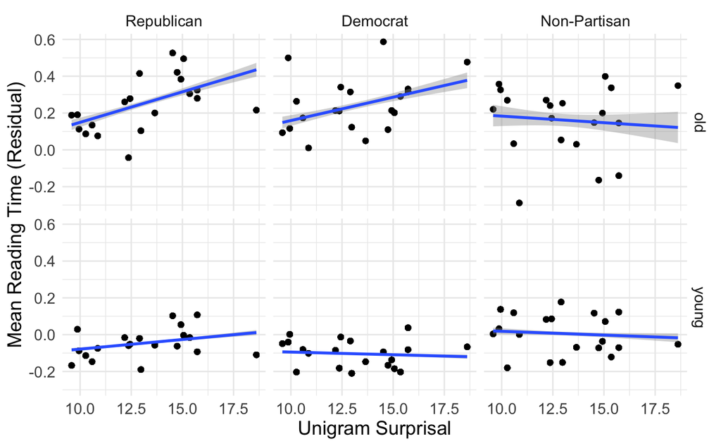

```r
final_spr %>%
  filter(!is.na(poli_party)) %>%
  filter(!is.na(young_old)) %>%
  group_by(form,poli_party,young_old) %>%
  mutate(resid_rt_mean = mean(resid_rt)) %>%
  filter(log_all > -5) %>%
  ggplot(aes(x=log_all,y=resid_rt_mean)) +
  geom_point() +
  geom_smooth(method="lm") +
  facet_grid(young_old~poli_party) +
  labs(x="Unigram Surprisal",y="Mean Reading Time (Residual)") +
  theme(text=element_text(size=14))
```

```r
ggsave("proc-freq-party.png", width=7,height=5,path='/Users/branpap/Desktop/gender_ideology/talks_and_papers/qp_paper/figures')
```